# EIOM 2024 Partie 1 - Analyse en composantes principales

Author

Anne-Sophie Charest

Published

August 28, 2024

Charger les librairies nécessaires :

```r
library(skimr)
library("ggplot2")
library("GGally")
library("factoextra")
```

# 1 Exemple avec les données USArrest

Cet exemple est basé sur le laboratoire sur l’ACP du livre *Introduction to Statistical Learning with Applications in R, second edition*, disponible gratuitement au http://www.statlearning.com.

## 1.1 Analyse exploratoire des données

On utilise le jeu de données USArrests disponible automatiquement avec le logiciel R.

### 1.1.1 Contenu du jeu de données

```r
#help(USArrests) #Enlever le premier signe de commentaire pour obtenir l'aide
head(USArrests)
```

```
           Murder Assault UrbanPop Rape
Alabama      13.2     236       58 21.2
Alaska       10.0     263       48 44.5
Arizona       8.1     294       80 31.0
Arkansas      8.8     190       50 19.5
California    9.0     276       91 40.6
Colorado      7.9     204       78 38.7
```

**Vos notes ici:** Le jeu de données contient…

### 1.1.2 Quelques statistiques descriptives univariées

```r
skimr::skim(USArrests)
```

Data summary

| Name | USArrests |
| --- | --- |
| Number of rows | 50 |
| Number of columns | 4 |
| _______________________ |  |
| Column type frequency: |  |
| numeric | 4 |
| ________________________ |  |
| Group variables | None |

**Variable type: numeric**

| skim_variable | n_missing | complete_rate | mean | sd | p0 | p25 | p50 | p75 | p100 | hist |
| --- | --- | --- | --- | --- | --- | --- | --- | --- | --- | --- |
| Murder | 0 | 1 | 7.79 | 4.36 | 0.8 | 4.08 | 7.25 | 11.25 | 17.4 | ▇▇▅▅▃ |
| Assault | 0 | 1 | 170.76 | 83.34 | 45.0 | 109.00 | 159.00 | 249.00 | 337.0 | ▆▇▃▅▃ |
| UrbanPop | 0 | 1 | 65.54 | 14.47 | 32.0 | 54.50 | 66.00 | 77.75 | 91.0 | ▁▆▇▅▆ |
| Rape | 0 | 1 | 21.23 | 9.37 | 7.3 | 15.08 | 20.10 | 26.17 | 46.0 | ▆▇▅▂▂ |

Que remarquez-vous?  
**Vos notes ici:**

### 1.1.3 Analyse de la corrélation entre les variables

Regardons maintenant la corrélation entre les variables. La fonction ci-dessous nous donne du même coup la densité de chacune des variables sur la diagonale, des nuages de points pour visualiser la relation entre les variables sous la diagonale et les coefficients de corrélation de Pearson entre chacune des paires au-dessus de la diagonale. Les astérisques donnent de l’information sur la valeur-p d’un test statistique dont l’hypothèse nulle est que la corrélation de Pearson entre les variables en question est égale à zéro (fonction `cor.test`).

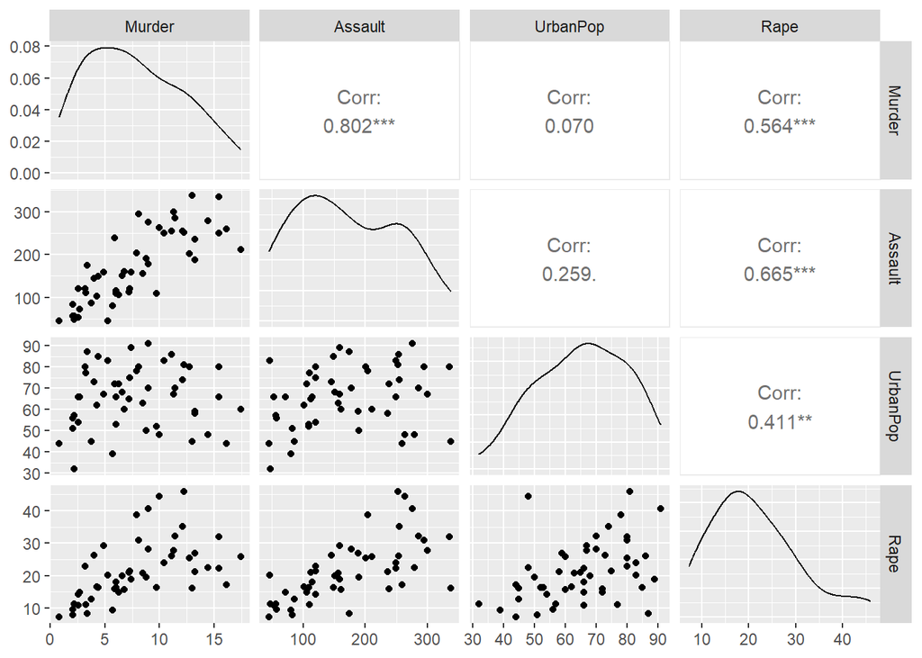

```r
GGally::ggpairs(USArrests)
```

Que remarquez-vous?  
**Vos notes ici:**

## 1.2 Analyse en composantes principales de la matrice de corrélation

On utilise pour cet exemple la fonction `prcomp` qui vient directement avec le logiciel R, ainsi que les fonctions graphiques de base. On commence par utiliser l’option `scale = TRUE` qui indique de standardiser les observations avant de faire l’ACP, ce qui correspond à faire l’ACP sur la matrice de corrélation. Que contient l’objet créé par la fonction `prcomp`?

```r
acp_USArrests <- prcomp(USArrests, scale = TRUE)
names(acp_USArrests)
```

```
[1] "sdev"     "rotation" "center"   "scale"    "x"
```

Deux des sous-objets donnent la moyenne et l’écart-type de chacune des variables, respectivement. Ces valeurs ont été utilisées pour standardiser les variables.

```r
acp_USArrests$center
```

```
  Murder  Assault UrbanPop     Rape
   7.788  170.760   65.540   21.232
```

```r
acp_USArrests$scale
```

```
   Murder   Assault  UrbanPop      Rape
 4.355510 83.337661 14.474763  9.366385
```

L’objet fournit également l’écart-type des composantes principales obtenues.

```r
acp_USArrests$sdev
```

```
[1] 1.5748783 0.9948694 0.5971291 0.4164494
```

On peut donc calculer la variance de chacun des composantes principales et vérifier si les premières composantes principales expliquent une grande partie de la variabilité dans les données.

```r
#Les variances
acp_var_USArrests <- acp_USArrests$sdev^2
acp_var_USArrests
```

```
[1] 2.4802416 0.9897652 0.3565632 0.1734301
```

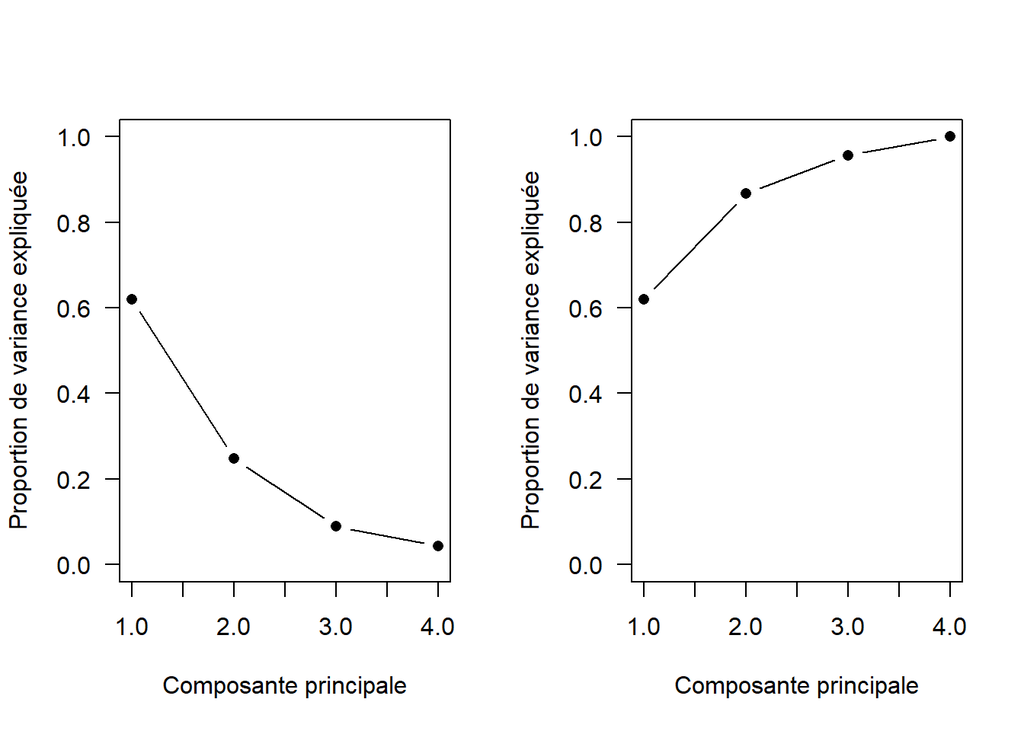

```r
#Proportion de variabilité expliquée par chaque composante
acp_var_prop_USArrests <- acp_var_USArrests / sum(acp_var_USArrests)

#Visualisation
par(mfrow = c(1, 2)) #Demande deux graphiques côte-à-côte
plot(acp_var_prop_USArrests,
     xlab = "Composante principale",
     ylab = "Proportion de variance expliquée",
     ylim = c(0, 1),
     type = "b",
     pch = 16,
     las = 1
     )
plot(cumsum(acp_var_prop_USArrests),
     xlab = "Composante principale",
     ylab = "Proportion de variance expliquée",
     ylim = c(0, 1),
     type = "b",
     pch = 16,
     las = 1
     )
```

```r
par(mfrow = c(1,1)) #Revient à un seul graphique
```

Que concluez-vous? Est-ce que ça semble une bonne idée de conserver quelques-unes des premières composantes principales?  
**Vos notes ici:**

Le sous-objet `rotation` contient quant à lui les composantes principales. Il permet de voir quelles variables sont associées à chacune des composantes.

```r
acp_USArrests$rotation
```

```
                PC1        PC2        PC3         PC4
Murder   -0.5358995 -0.4181809  0.3412327  0.64922780
Assault  -0.5831836 -0.1879856  0.2681484 -0.74340748
UrbanPop -0.2781909  0.8728062  0.3780158  0.13387773
Rape     -0.5434321  0.1673186 -0.8177779  0.08902432
```

Que concluez-vous? **Vos notes ici:**

Enfin, le sous-objet `x` donne les scores de toutes les observations dans l’espace des nouvelles composantes principales.

```r
head(acp_USArrests$x)
```

```
                  PC1        PC2         PC3          PC4
Alabama    -0.9756604 -1.1220012  0.43980366  0.154696581
Alaska     -1.9305379 -1.0624269 -2.01950027 -0.434175454
Arizona    -1.7454429  0.7384595 -0.05423025 -0.826264240
Arkansas    0.1399989 -1.1085423 -0.11342217 -0.180973554
California -2.4986128  1.5274267 -0.59254100 -0.338559240
Colorado   -1.4993407  0.9776297 -1.08400162  0.001450164
```

Il peut être intéressant de visualiser les composantes principales. Pour ce faire, on se limitera généralement à deux composantes.

On peut visualiser les contributions des variables aux deux composantes principales.

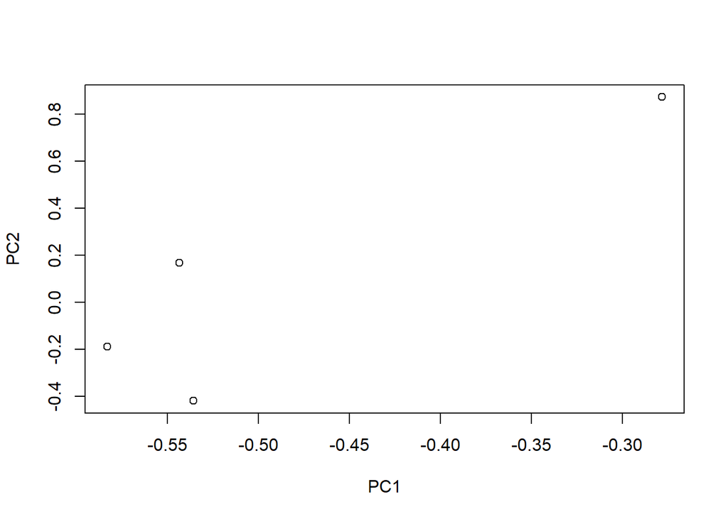

```r
#Graphique des variables
plot(acp_USArrests$rotation[,1:2])
```

Chacun des points correspond à une des variables. Etes-vous capable de faire l’association? **Vos notes ici:**

On peut aussi visualiser les observations dans l’espace des deux composantes principales.

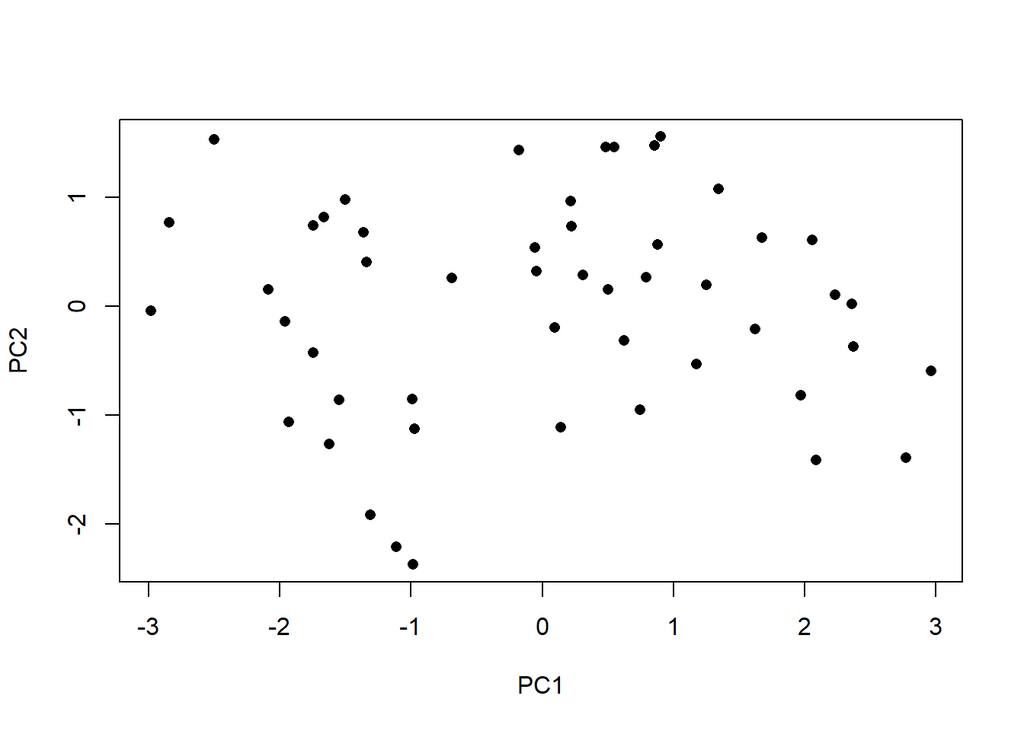

```r
plot(acp_USArrests$x[,1:2], pch = 16)
```

Quelle est l’observation dans le coin supérieur gauche du graphique? **Vos notes ici:**

Bien sûr, les deux derniers graphiques produits sont peu informatifs. Il faudrait ajouter de l’information sur les points dans le graphique. La fonction `biplot` produit automatiquement une visualisation des variables et des observations avec cette information.

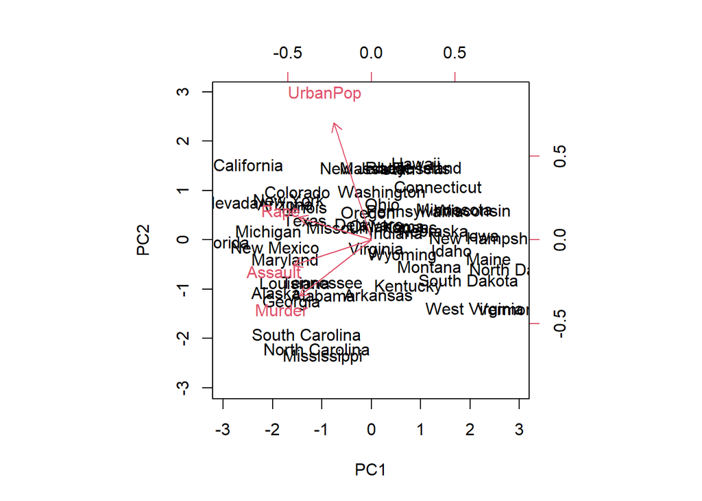

```r
biplot(acp_USArrests, scale = 0)
```

Rappelez-vous que les composantes principales sont uniques, sauf pour un changement de signe. On peut donc modifier un peu le graphique pour en faciliter l’interprétation. On copie la sortie et on modifie le signe des composantes.

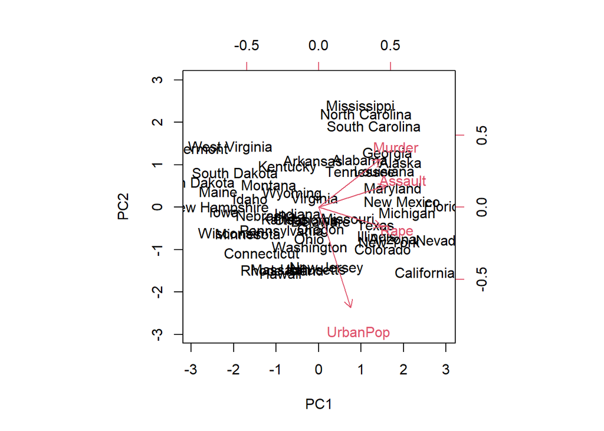

```r
acp_USArrests_v2 <- acp_USArrests
acp_USArrests_v2$rotation <- -acp_USArrests$rotation
acp_USArrests_v2$x <- -acp_USArrests$x
biplot(acp_USArrests_v2, scale = 0)
```

Le graphique reste compliqué à lire car trop chargé. On verra plus loin une alternative en utilisant les fonctions d’une autre librairie.

## 1.3 Analyse en composantes principales de la matrice de covariance

Si on utilise l’option `scale = FALSE` dans la fonction `prcomp`, les variables seront utilisées telles qu’elles, sans standardisation. On obtiendra ainsi l’ACP de la matrice de covariance au lieu de l’ACP de la matrice de corrélation. Quel sera à votre avis l’impact sur les résultats? Vérifiez votre intutition.

```r
acp_USArrests_noscale <- prcomp(USArrests, scale = FALSE)
```

**Vos notes ici:**

# 2 Exemple avec des données de décathlon

Ce deuxième exemple inspiré de celui-ci http://www.sthda.com/english/articles/31-principal-component-methods-in-r-practical-guide/118-principal-component-analysis-in-r-prcomp-vs-princomp/.

On utilise cette fois des données dans la librairie `factoextra`. On en profite pour utiliser des fonctions de la librairie qui sont plus intéressantes pour la visualisation. Le jeu de données se nomme `decathlon2`. Les 10 premières colonnes donnent les résultats de plusieurs athlètes à 10 épreuves lors d’une compétition de décathlon. Viennent ensuite le classement de chacun et le nombre de points accumulés, puis une variable indiquant de quel type de compétition il s’agit. On utilisera que les 23 premiers athlètes.

```r
data(decathlon2)
head(decathlon2)
```

```
          X100m Long.jump Shot.put High.jump X400m X110m.hurdle Discus
SEBRLE    11.04      7.58    14.83      2.07 49.81        14.69  43.75
CLAY      10.76      7.40    14.26      1.86 49.37        14.05  50.72
BERNARD   11.02      7.23    14.25      1.92 48.93        14.99  40.87
YURKOV    11.34      7.09    15.19      2.10 50.42        15.31  46.26
ZSIVOCZKY 11.13      7.30    13.48      2.01 48.62        14.17  45.67
McMULLEN  10.83      7.31    13.76      2.13 49.91        14.38  44.41
          Pole.vault Javeline X1500m Rank Points Competition
SEBRLE          5.02    63.19  291.7    1   8217    Decastar
CLAY            4.92    60.15  301.5    2   8122    Decastar
BERNARD         5.32    62.77  280.1    4   8067    Decastar
YURKOV          4.72    63.44  276.4    5   8036    Decastar
ZSIVOCZKY       4.42    55.37  268.0    7   8004    Decastar
McMULLEN        4.42    56.37  285.1    8   7995    Decastar
```

```r
#help(decathlon2)
```

## 2.1 Obtenir les composantes principales

Je vous fournis les codes.

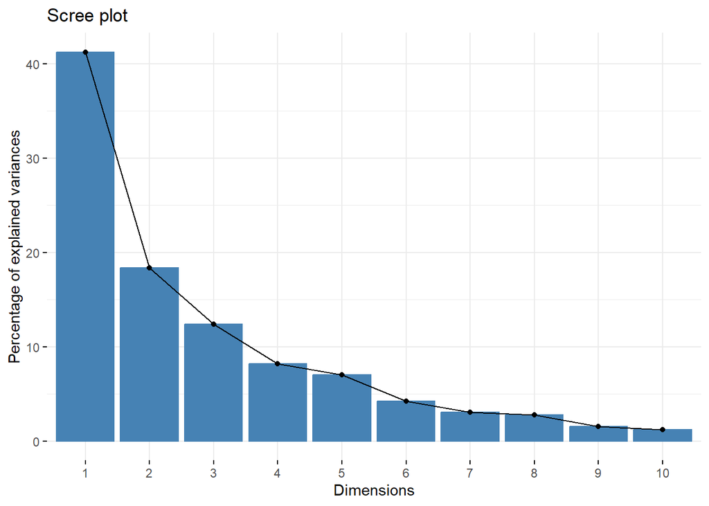

```r
pca_decathlon2 <- prcomp(decathlon2[1:23,1:10], scale = TRUE)

#Regarder la variance expliquée
fviz_eig(pca_decathlon2)
```

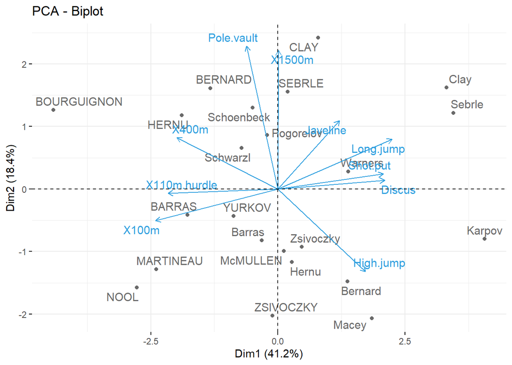

```r
#Bi-plot
fviz_pca_biplot(pca_decathlon2,
                repel = TRUE,
                col.var = "#2E9FDF", # Couleur variables
                col.ind = "#696969"  # Couleur individus
                )
```

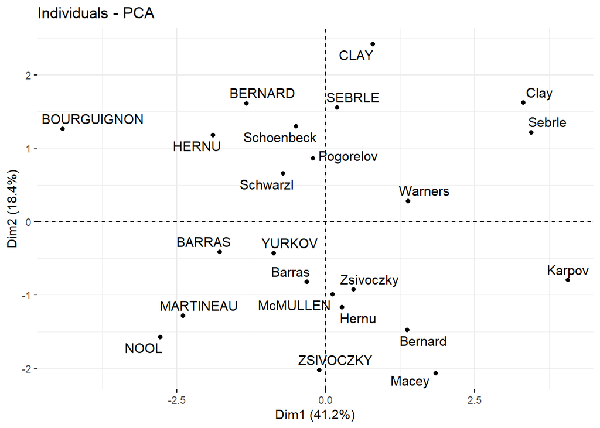

```r
#Graphique des individus
fviz_pca_ind(pca_decathlon2,
             repel = TRUE
             )
```

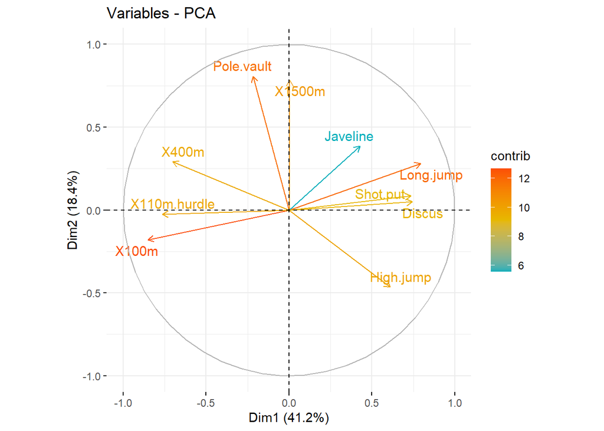

```r
#Graphique des variables
fviz_pca_var(pca_decathlon2,
             col.var = "contrib",
             gradient.cols = c("#00AFBB", "#E7B800", "#FC4E07"),
             repel = TRUE
             )
```

Quelles sont vos conclusions? **Vos notes ici:**

## 2.2 Positionner un individu additionnel

Une première option est d’utiliser la fonction predict sur l’objet retourné par prcomp.

```r
individus_sup <- decathlon2[24:27, 1:10]
individus_sup_coord <- predict(pca_decathlon2, newdata = individus_sup)
individus_sup_coord
```

```
               PC1         PC2       PC3        PC4         PC5       PC6
KARPOV   0.7772521  0.76237804 1.5971253  1.6863286 -0.73420295 0.8764709
WARNERS -0.3779697 -0.11891968 1.7005146 -0.6908084 -0.03159013 1.1580162
Nool    -0.5468405  1.93402211 0.4724184 -2.2283706 -0.24901831 0.5459418
Drews   -1.0848227  0.01703198 2.9818031 -1.5006207 -0.31924693 0.4645028
               PC7         PC8         PC9       PC10
KARPOV  -1.0746432  1.24674643 -1.09172761 -0.2155002
WARNERS -0.3181706 -0.41754716 -0.69099653  0.5251023
Nool    -0.4656852 -0.05883861  0.65860586 -0.2815011
Drews    0.3406706  0.01529952 -0.01678235 -0.1657992
```

Que fait cette fonction exactement? On peut reproduire nous-mêmes ces résultats avec quelques calculs. On standardise d’abord les variables des nouvelles observations avec les moyennes et écarts-types utilisés pour l’ACP.

```r
individus_scaled <- scale(individus_sup,
                    center = pca_decathlon2$center,
                    scale = pca_decathlon2$scale)
```

On définit maintenant une fonction pour calculer les coordonnées des individus à partir de leurs variables et de la matrice des composantes principales.

```r
calcul.coord <- function(individus, loadings){
  r <- loadings*individus
  apply(r, 2, sum)
}
```

On applique ensuite cette fonction à notre matrice de données et on peut vérifier que les deux méthodes donnent les mêmes résultats

```r
individus_sup_coord_v2 <- t(apply(individus_scaled, 1, calcul.coord, pca_decathlon2$rotation ))

max(individus_sup_coord_v2 - individus_sup_coord)
```

```
[1] 2.220446e-16
```

Et on peut facilement ajouter ces nouvelles observations à notre graphique des individus.

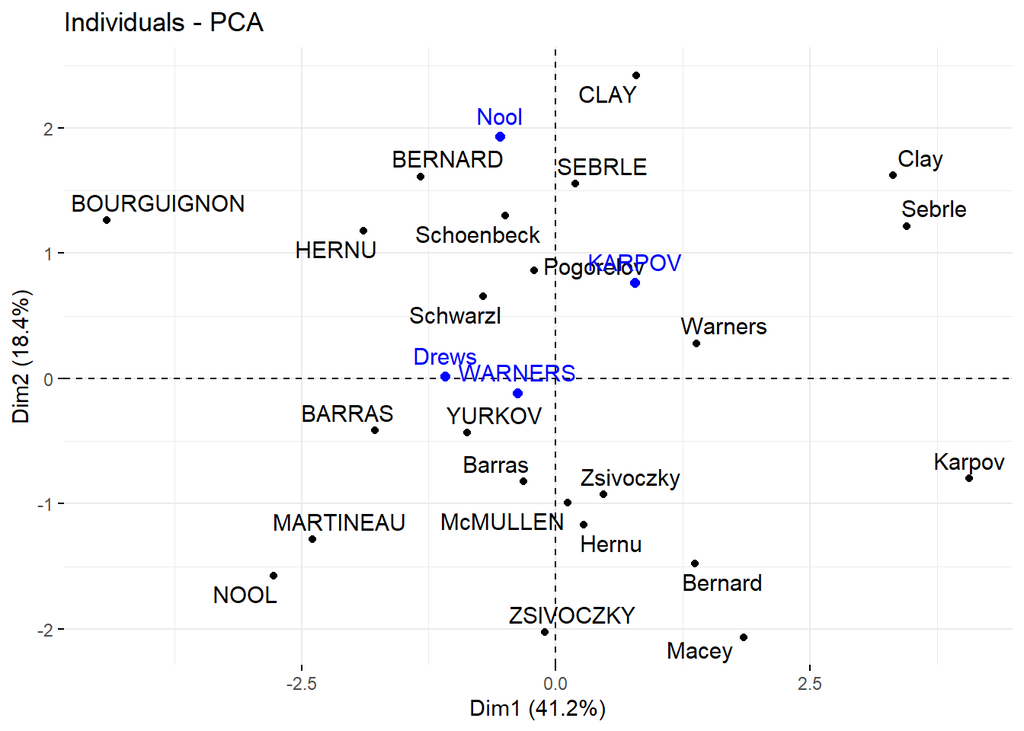

```r
graph_individus_decathlon <- fviz_pca_ind(pca_decathlon2, repel = TRUE)
fviz_add(graph_individus_decathlon, individus_sup_coord, color ="blue")
```

## 2.3 Ajouter une variable catégorique supplémentaire sur le graphique

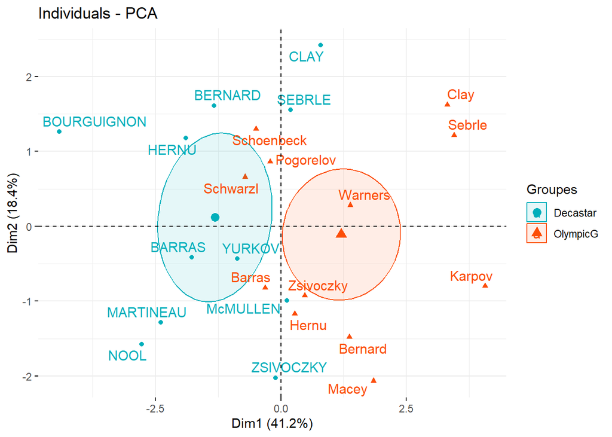

```r
groups <- as.factor(decathlon2$Competition[1:23])
fviz_pca_ind(pca_decathlon2,
             col.ind = groups, # Couleur selon le groupe
             palette = c("#00AFBB",  "#FC4E07"),
             addEllipses = TRUE, #
             ellipse.type = "confidence",
             legend.title = "Groupes",
             repel = TRUE
             )
```

Que représentent les ellipses dans le graphique? Validez votre intuition en cherchant dans l’aide.

**Vos notes ici:**